# HW 6: Beta binomial

Brenda Onyango

9/30/2021

### Load packages needed for assignment.

```r
library(tidyverse)
library(bayesrules)
```

## Exercise 3.1: Tuning

1. A friend puts their chance of getting a job between .2 and .6. To tune we need to think about the average. We know that E($\pi$) = $\alpha$/($\alpha$ + $\beta$)

```r
averagejob <- (.2+.6)/2 #we'll use this as our prior average
```

We also need a variance. If we assume a uniform distribution between 0.2 and 0.6 then variance can be found with var(pi) = 1/12(b-a)^2

```r
varpi <- (1/12) * (.6-.2)^2
```

Now with varpi of 0.0133 and average of 0.4 we can rearrange E(pi) and var(pi) to solve for alpha and beta.

.4 = alpha/alpha + beta .4(alpha +beta) = alpha .4beta = .6alpha (2/3) beta = alpha

solving for beta gives beta = 10.5

Plugging 10.5 in the mean formula gives alpha 7.

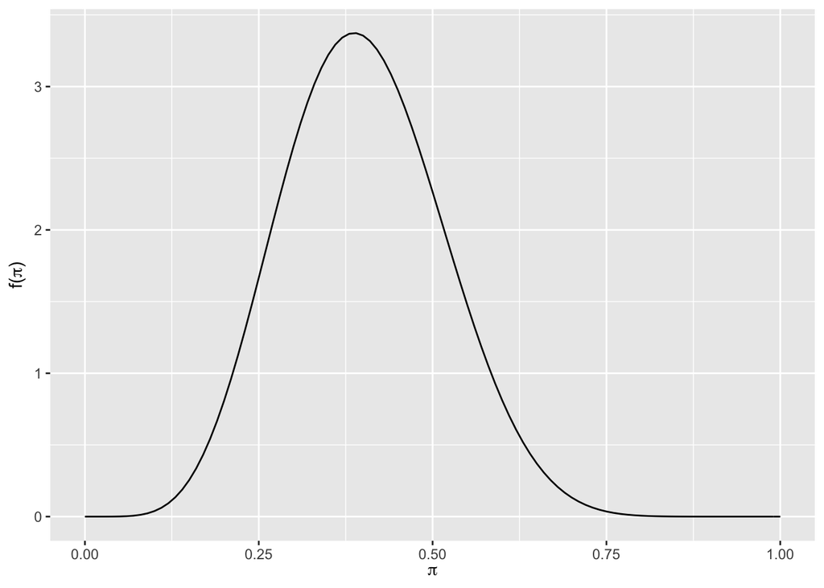

```r
plot_beta(7, 10.5) #this Beta shows I think he's more likely to not get the job
```

2. A test is accurate .8 of the time with a variance of 0.05. We remember that variance = $\alpha$ * $\beta$/($\alpha$ + $\beta$)^2 * ($\alpha$ + $\beta$ +1) and we will treat .8 as the mean.

.8 = alpha/alpha + beta .8(alpha + beta) = alpha .8beta = .2alpha

4beta = alpha variance = alpha*beta/(alpha + beta)^2* (alpha + beta + 1) replace alpha with 4beta and solve for beta with variance equal to 0.05

0.05 = 4/25 *(5beta + 1)

solving for beta gives .44 and using this in 4beta = alpha gives alpha of 1.76

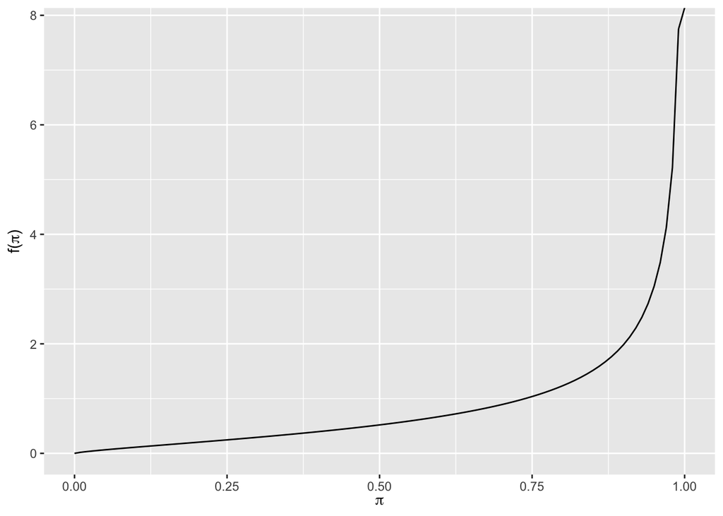

```r
plot_beta(1.75,.44) #gives left skewed Beta model.
```

3. Aunt Jo has finds mushrooms between .85 and .1 of the time. For this problem I’m going to find the average of .85 and 1 to use as the prior to estimate $\alpha$ and $\beta$ using the E($\pi$) formula. The average is .925 ot 37/40 so .925 = alpha/(alpha + beta).

0.925 = alpha/alpha + beta .925alpha + 0.925 beta = alpha

(37/3)beta = alpha

Setting beta to 3 gives alpha of 37.

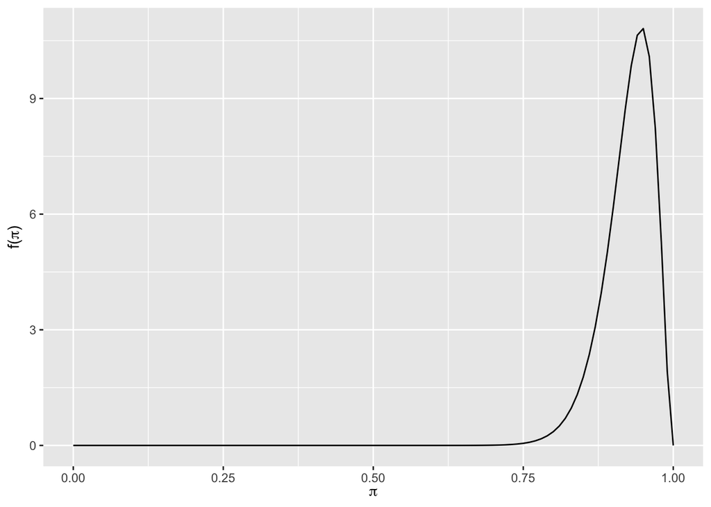

```r
plot_beta(37,3) #plot is left skewed so it shows that Aunt Jo has a high probability of finding mushrooms
```

4. Sal has either done really well or completely bombed the interview so I interpret this as .5 probabilities for both outcomes.

```r
plot_beta(0.5,0.5) #Plot shows f(pi) being high near 0 and 1 but low in the middle which matches Sal's description of either doing really well or terribly.
```

[output not shown]

## Exercise 3.2

1. I’ll take an average of .7 and .9 to use .8 as the average. .8 = alpha/(alpha + beta). .8alpha + .8beta = alpha 4beta = alpha So if I set beta to 4 alpha = 16

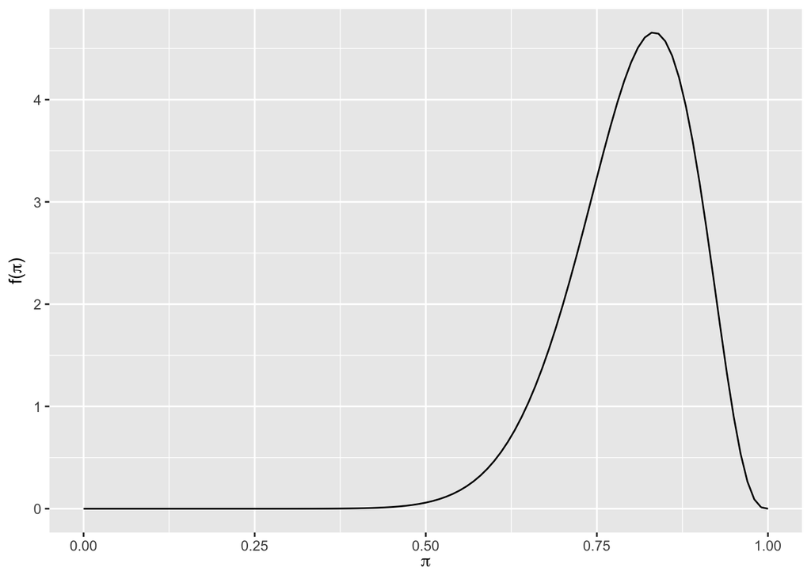

```r
plot_beta(16,4) #most likkely pi is between 0.7 and .90
```

2. We’re given variance = .08 and mean = .90

.90 = alpha/alpha + beta .90alpha +.90 beta = alpha 9beta = alpha

Plugging this value for alpha in the variance equation we get 9beta*beta/(9beta + beta)^2* (9beta + beta + 1 )= .08

9/100 * (10beta + 1) = 0.08 9= 80beta + 8 1= 80beta beta = 1/80 = 0.0125

9beta = alpha = .1125

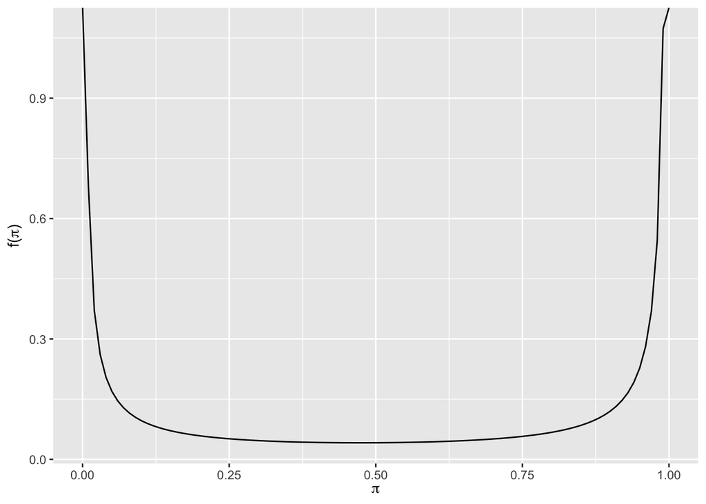

```r
plot_beta(.1125,0.0125) #gives a model with variance = 0.08 and mean of .90
```

```r
summarize_beta(.1125,0.0125)
```

```
##   mean    mode  var        sd
## 1  0.9 0 and 1 0.08 0.2828427
```

3. The friend says the most likley pi =.85 so I will use this and the average formula to find a beta model. .85 = alpha / aplpha + beta.

.85alpha + .85beta = alpha (17/3)beta = alpha

If I set beta = 3 alpha = 17.

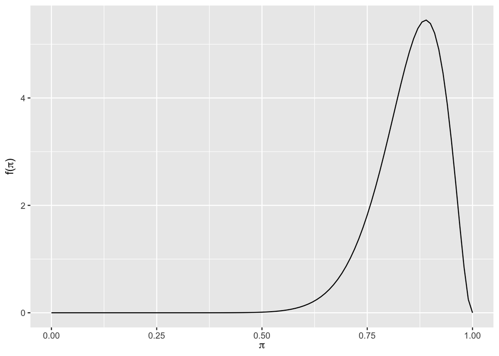

```r
plot_beta(17, 3)
```

4. Ben thinks pi of running out of croissants is .3 but isn’t confident about this so there will be a wide “band” around .3. Using 3/10 = alpha/alpha + beta

.3alpha + .3beta = alpha (3/7)beta = alpha

If I set beta to 7, alpha = 3

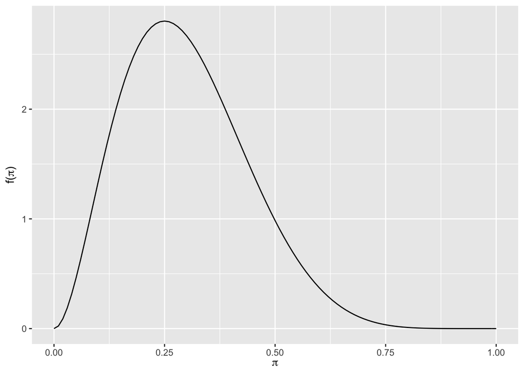

```r
plot_beta(3,7) #This plot has a large band around .3 that indicates his uncertainty
```

```r
summarize_beta(3,7)
```

```
##   mean mode        var        sd
## 1  0.3 0.25 0.01909091 0.1381699
```

## Exercise 3.3

1. I selected the uniform model which the text describes as being useful for when pi can plausibly be between 0 and 1. Beta(1,1).

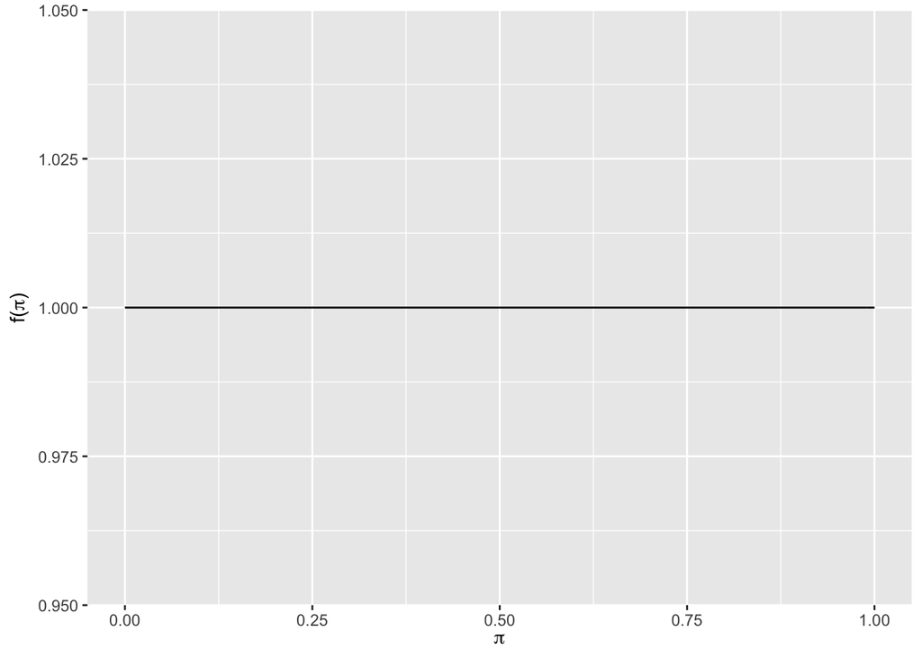

```r
plot_beta(1,1)
```

2. Mean is found with alpha/(alpha + beta).

```r
1/(1+1) #finding mean of the uniform model
```

```
## [1] 0.5
```

This mean does align with having no clue because it means pi is just as likely as it is unlikely.

3. What is the standard deviation of the uniform model or Beta(1,1). Standard deviation is the square root of the variance. Variance equals alpha*beta/(alpha+beta)^2* (alpha + beta + 1)

```r
a <- 1
b <- 1 #setting alpha and beta to 1 prior to solving for variance

variance <- a*b/((a+b)^2 * (a+ b + 1))
```

Variance = .083 Now to find standard deviation we’ll take the square root of the variance.

```r
sd <- sqrt(variance) #finding standard deviation
```

3. Specify and plot an example of a Beta prior with a SD < 0.2886. I did guess and check to find a an alpha and beta that meets this criteria.

```r
A <- 2 #setting alpha and beta greater than 1
B <- 2
VAR <- A*B/((A+B)^2 * (A+ B +1)) #named alpha, beta, var, and sd with caps to distinguis from earlier
SD <- sqrt(VAR)
```

Next I’ll plot this.

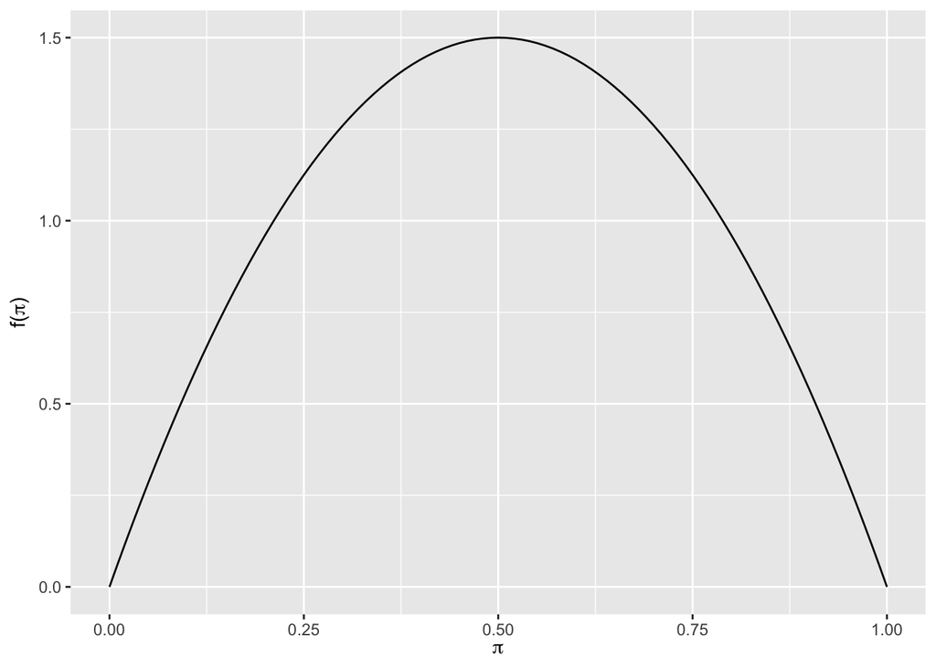

```r
plot_beta(2,2)
```

4. Specify and plot an example of a Beta prior with a SD > 0.2886. I did guess and check to find a an alpha and beta that meets this criteria.

```r
aa <- .5 #setting alpha and beta below 1 to see if sd is less than initial sd
bb <- .5
var <- aa*bb/((aa + bb)^2 * (aa+ bb + 1))  #finding variance prior to sd
sdd <- sqrt(var) #finding sd. Named these variables as "aa" and "bb" to distinguish between part c
```

```r
plot_beta(.5, .5)
```

[output not shown]

## Exercise 3.4

1. a = Beta(0.5, 0.50) I plotted this in the prior exercise.
2. b = Beta(2,2) This plot has symmetry implying beta = alpha and the shape implies beta and alpha that are greater than 1.
3. c = Beta(6,2) pdfs are left-skewed when alpha>beta.
4. d = Beta(1,1) Uniform model.
5. e = Beta(0.5,6) pdfs are right-skewed when alpha<beta.
6. f = Beta(6,6) This is also symmetrical like b, but has a higher beta and alpha meaning more certainty around a pi.

## Exercise 3.5

1. a = Beta(1, 0.3) Here alpha > beta and the way the plot increases indicates beta is less than 1.
2. b = Beta(3,3) This is symmetrical so alpha = beta.
3. c = Beta(4,2) This is left skewed with alpha > beta but not to the extreme of a.
4. d = Beta(2,1) alpha>beta and looks like an adjusted uniform model.
5. e = Beta(5,6) This is slightly right-skewed where beta>alpha.
6. f = Beta(6,3) This is left-skewed and narrower than c where alpha > beta.

## Exercise 3.6

1. Which beta models in 3.4 had the smallest and largest mean?

E(pi) = alpha/alpha + beta. E(pi) is smallest when the numerator is much smaller than the denominator (small/big = small number). Therefore Beta(0.5,6) has the smallest mean and equals 0.0769.

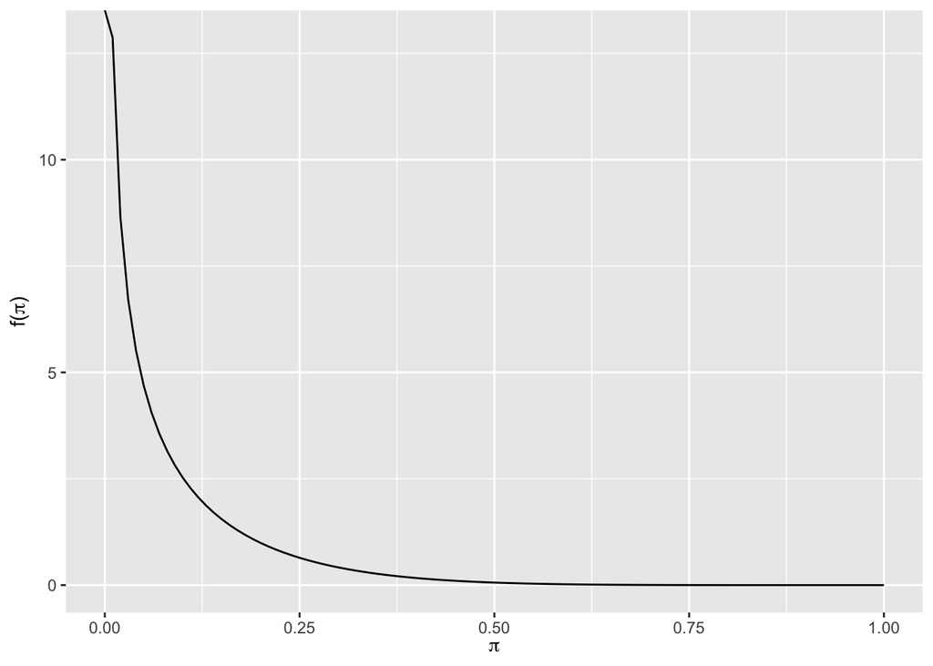

```r
plot_beta(0.5,6) #during in class review ask how to add mean line
```

The largest mean is when the numerator is much larger than the denominator (big/small = big number). The largest mean is for Beta(6,2) and equals 0.75.

```r
plot_beta(6,2)
```

[output not shown]

2. Which models have the smallest and biggest mode?

```r
maxmode <- (6-1)/(6 + 2 -2)
minmode <- (2-1)/(2+2-2)
```

```r
plot_beta(6,2)
```

[output not shown]

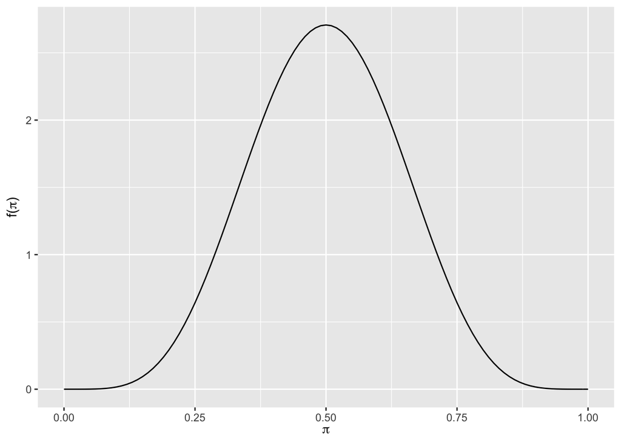

```r
plot_beta(6,6)
```

3. Which beta model has the smallest standard deviation. Standard deviation = sqrt of alpha*beta/(alpha + beta)^2* (alpha + beta + 1) Let’s write a chunk that will allow us to explore trends in standard deviation of all beta models in 3.4.

```r
alpha <- c(0.5, 2, 6, 1, 0.5, 6)
beta <- c(0.5, 2, 2, 1, 6, 6)
result <- sqrt(alpha*beta/((alpha +beta)^2 *(alpha + beta + 1))) #taking square root of variance
view(result)
```

## Exercise 3.7

1. use plot_beta and summarize_beta to plot and confirm 3.6.

```r
plot_beta(0.5, 0.5)
```

[output not shown]

```r
summarize_beta(0.5,0.5)
```

```
##   mean    mode   var        sd
## 1  0.5 0 and 1 0.125 0.3535534
```

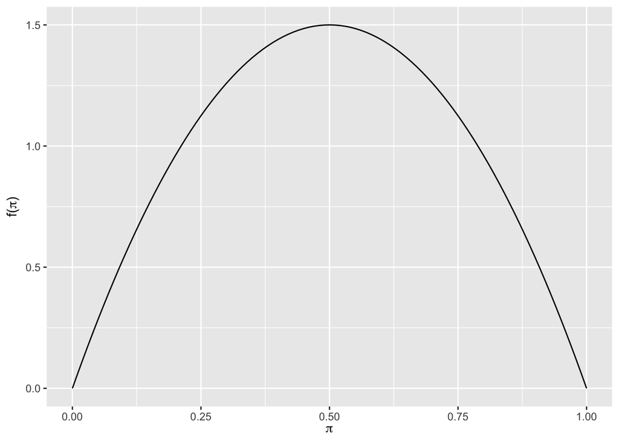

```r
plot_beta(2,2)
```

```r
summarize_beta(2,2)
```

```
##   mean mode  var        sd
## 1  0.5  0.5 0.05 0.2236068
```

```r
plot_beta(6,2)
```

[output not shown]

```r
summarize_beta(6,2)
```

```
##   mean      mode        var        sd
## 1 0.75 0.8333333 0.02083333 0.1443376
```

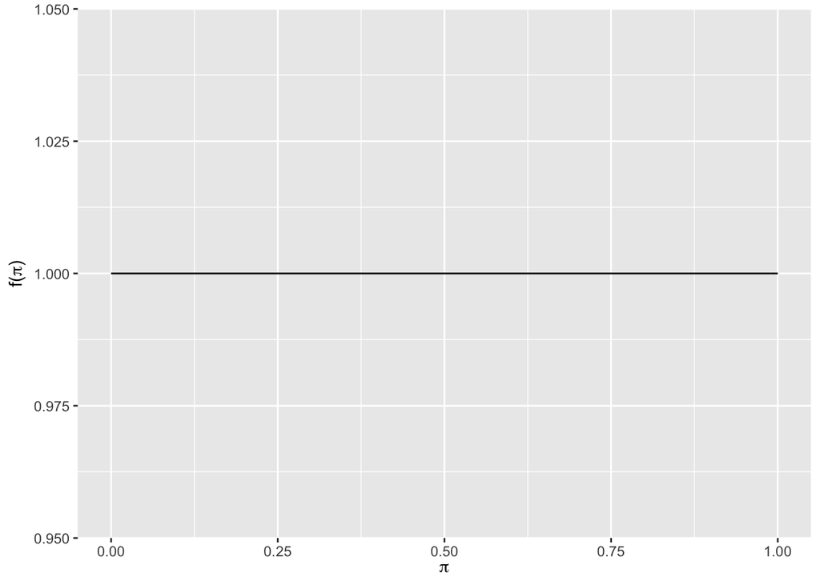

```r
plot_beta(1,1)
```

```r
summarize_beta(1,1)
```

```
##   mean mode        var        sd
## 1  0.5  NaN 0.08333333 0.2886751
```

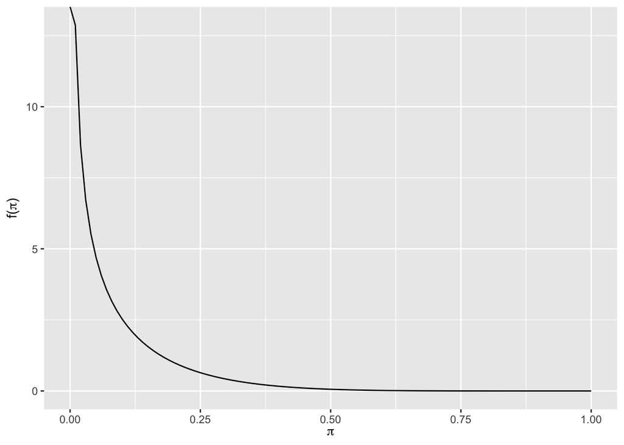

```r
plot_beta(0.5, 6)
```

```r
summarize_beta(0.5, 6)
```

```
##         mean mode         var         sd
## 1 0.07692308    0 0.009467456 0.09730085
```

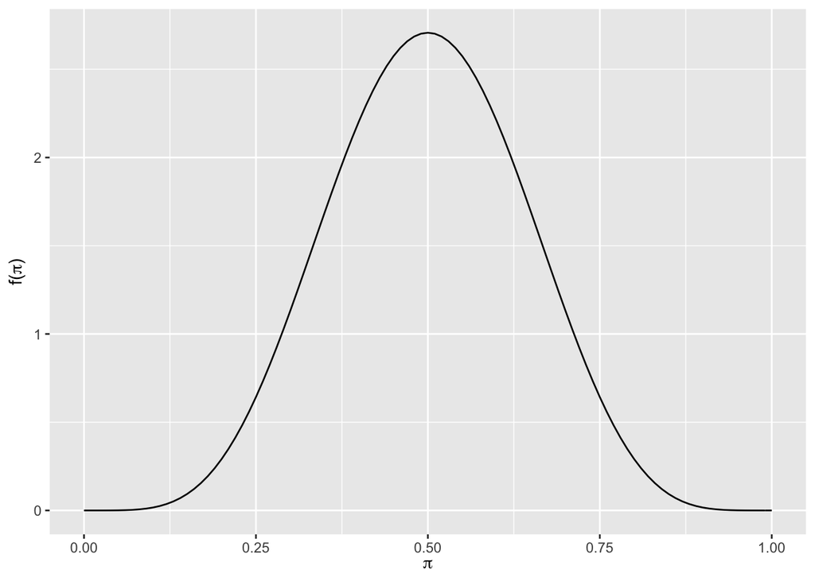

```r
plot_beta(6,6)
```

```r
summarize_beta(6,6)
```

```
##   mean mode        var       sd
## 1  0.5  0.5 0.01923077 0.138675
```

## Exercise 3.9

1. Calculate prior mean, mode, and standard deviation of pi for the North Dakota and Louisiana salesmen.

```r
alphad <- c(8,1) #alpha of drink
betad <- c(2,20)
meandrink <- alphad/(alphad+betad)
modedrink <- (alphad-1)/(alphad + betad - 2)
sddrink <- sqrt(alphad*betad/((alphad+betad)^2 * (alphad + betad + 1)))
```

Prior mean, mode, and sd for the North Dakota salesman is 0.8, 0.875, and 0.1206 respectively. For the Louisiana salesmen it is 0.0476, 0, and 0.0454.

I could have also used summarize_beta.

```r
summarize_beta(8,2)
```

```
##   mean  mode        var        sd
## 1  0.8 0.875 0.01454545 0.1206045
```

```r
summarize_beta(1,20)
```

```
##         mean mode         var         sd
## 1 0.04761905    0 0.002061431 0.04540298
```

2. plot prior pdfs for both salesmen.

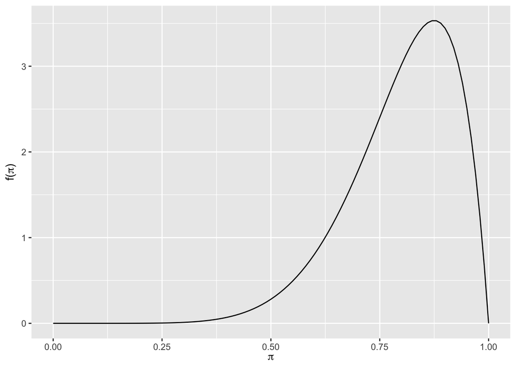

```r
plot_beta(8,2)
```

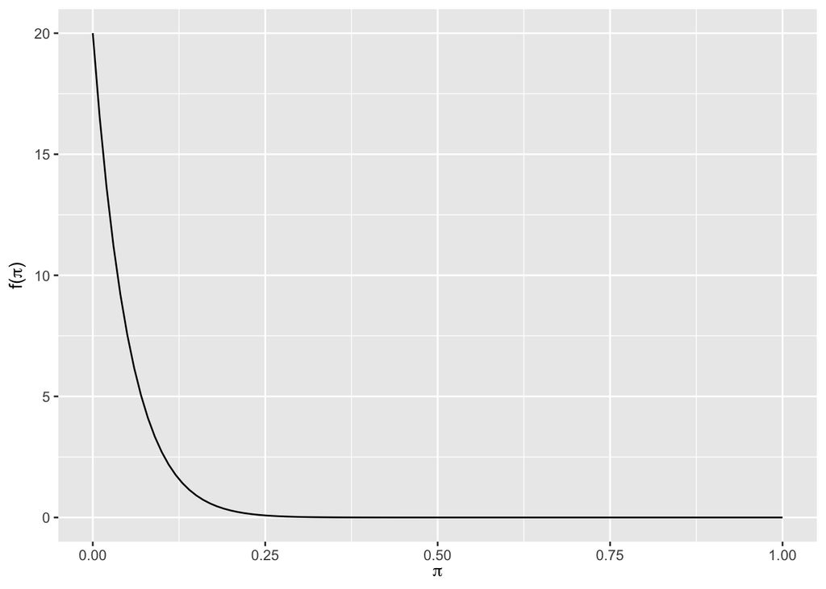

```r
plot_beta(1,20)
```

## Exercise 3.10

a&b) Specify posterior model pi for North Dakota salesmen. Y|pi~Bin(50, pi) and pi~Beta(8,2) is the Beta posterior model. I can find this using plot_beta_binomial.

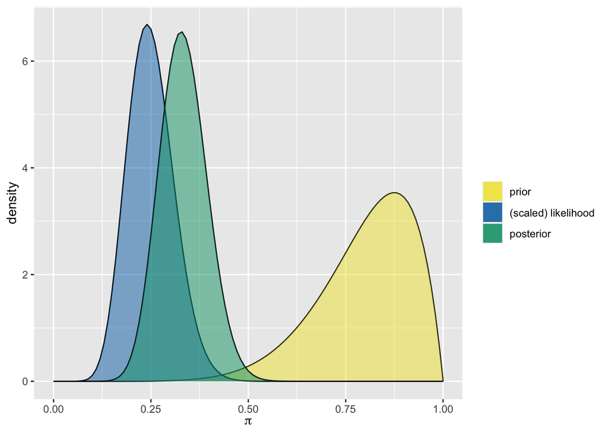

```r
plot_beta_binomial(alpha = 8, beta = 2, y = 12, n = 50)
```

Posterior for Louisiana salesmen.Y|pi~Bin(50, pi) and pi~Beta(1,20) I can find this using plot_beta_binomial.

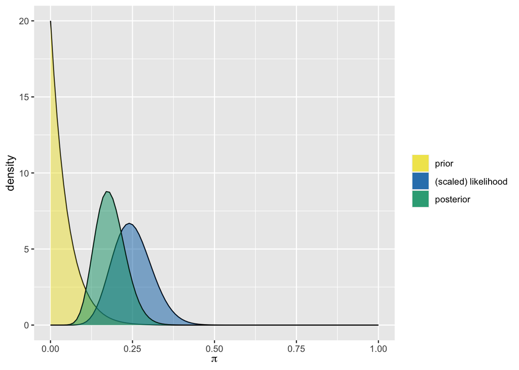

```r
plot_beta_binomial(alpha = 1, beta = 20, y= 12, n= 50)
```

3. We can use summmarize_beta_binomial to understand how the salemen’ understandings changed. The Louisiana salesman had a better prior understanding than did the North Dakota salesman. His posterior has less variance.

```r
summarize_beta_binomial(alpha = 8, beta = 2, y = 12, n = 50) #North Dakota
```

```
##       model alpha beta      mean      mode         var         sd
## 1     prior     8    2 0.8000000 0.8750000 0.014545455 0.12060454
## 2 posterior    20   40 0.3333333 0.3275862 0.003642987 0.06035716
```

```r
summarize_beta_binomial(alpha = 1, beta = 20, y= 12, n= 50) #Louisiana
```

```
##       model alpha beta       mean     mode         var         sd
## 1     prior     1   20 0.04761905 0.000000 0.002061431 0.04540298
## 2 posterior    13   58 0.18309859 0.173913 0.002077410 0.04557861
```

## Exercise 3.11

1. Mean is given as .25 and mode is 5/22.

```r
meanstudent <- .25
modestudent <- 5/22
```

I used these values to solve for alpha and beta by first finding what alpha equals using the mean and then plugging that into the formula for mode.

1. .25 = alpha/alpha + beta (alpha + beta)0.25 = alpha alpha + beta = 4alpha
2. (5/22) = alpha-1/alpha + beta - 2 Using what we found in step 1 replace alpha + beta with 4 alpha.

(5/22) = alpha - 1/(4alpha -2). At this stage we can sovle for alpha.

(5/22)(4alpha -2) = alpha - 1

*distribute 5/22*

(10/11)alpha - (5/11) = alpha - 1

*get all alphas to 1 side)*

(10/11)alpha + (6/11) = alpha

(6/11) = (1/11)alpha

alpha = 6. Now with alpha equal to 6 we can find Beta using the rearranged formula for mean. beta = 4alpha - alpha

```r
betastudent <- 4*6 - 6
```

Now with alpha and beta we can use plot_beta to plot prior understanding.

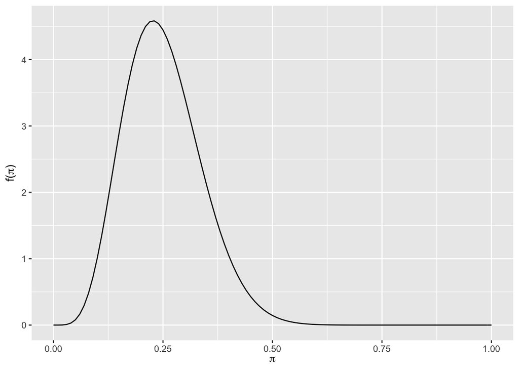

```r
plot_beta(6,18)
```

b & c) What is the posterior model?

```r
summarize_beta_binomial(alpha = 6, beta = 18, y = 15, n = 50)
```

```
##       model alpha beta      mean      mode         var         sd
## 1     prior     6   18 0.2500000 0.2272727 0.007500000 0.08660254
## 2 posterior    21   53 0.2837838 0.2777778 0.002710007 0.05205773
```

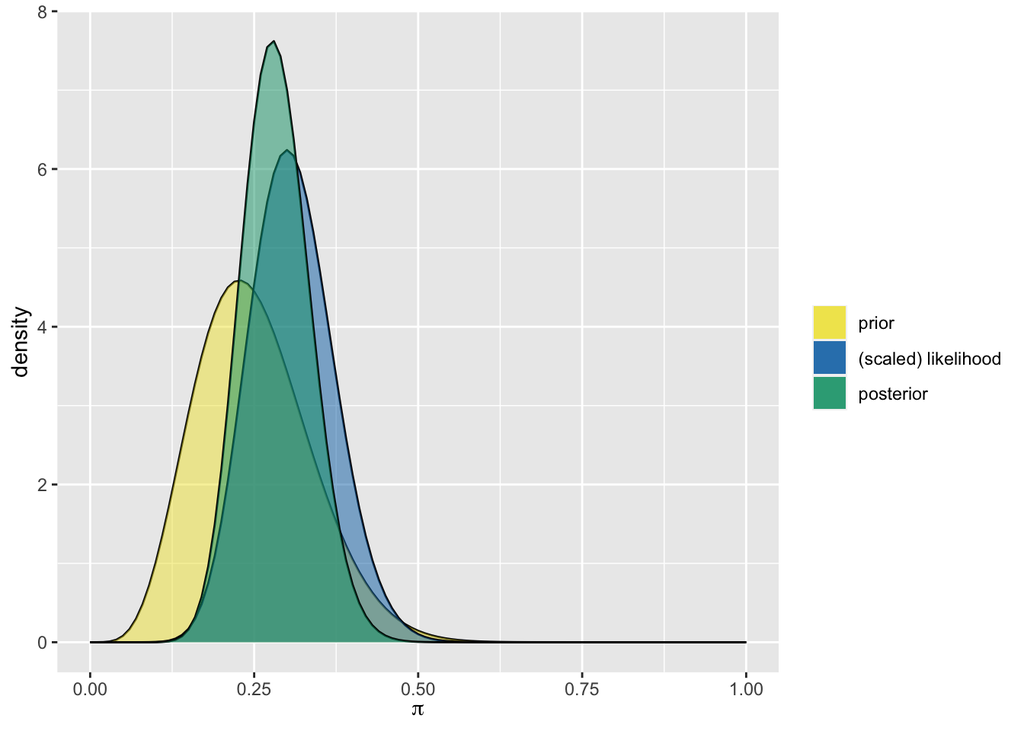

```r
plot_beta_binomial(alpha = 6, beta = 18, y = 15, n = 50)
```

4. The university now has a lot more confidence that slightly over 1 in 4 students would use a bike. The posterior model is Beta(21,53). The posterior reflects the liklihood. They have similar peaks and width.

## Exercise 3.12

1. The average of .1 and .25 is 0.175. We’ll use this as the average to find alpha and beta. After some rearranging we have (7/33)beta = alpha. If we set Beta to 33 then alpha = 7.

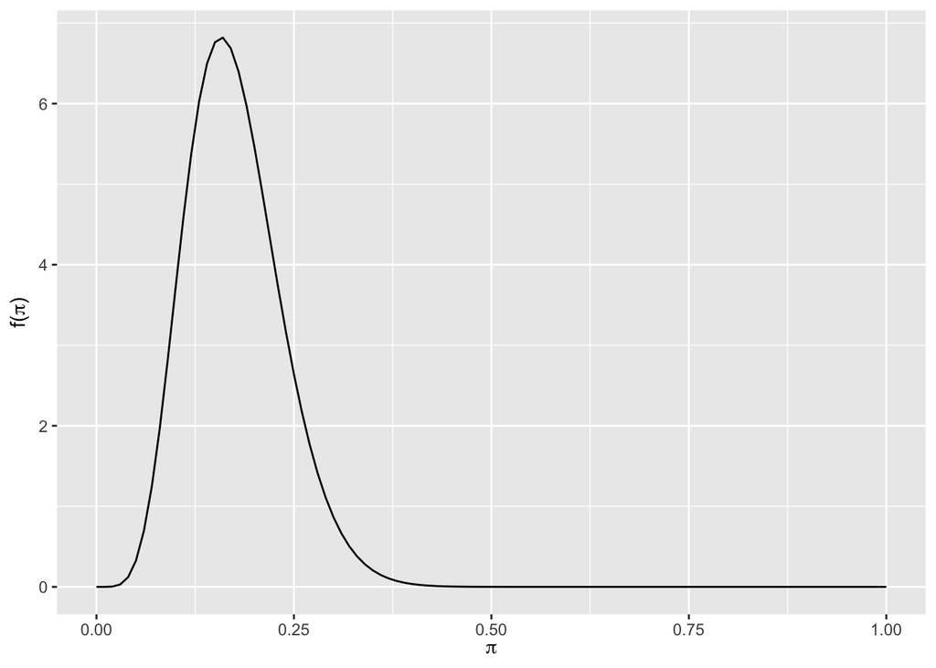

```r
plot_beta(7,33)
```

b &c) Update this prior with y =30 and n = 90.

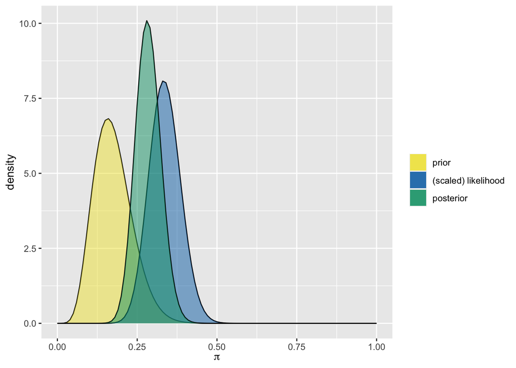

```r
plot_beta_binomial(alpha = 7, beta = 33, y = 30, n = 90)
```

```r
summarize_beta_binomial(alpha = 7, beta = 33, y = 30, n = 50)
```

[output not shown]

4. Does posterior model closely reflect the prior information or data?

The posterio reflects the likelihood. The posterior has a much higher mean and mode than did the prior.

## Exercise 3.13

1. We’ll use the average of .35 and .6 to find an average for pi to find the ratio of beta to alpha.

```r
(.35 + .6)/2
```

```
## [1] 0.475
```

Setting .475 or 19/40 equal to alpha/alpha + beta gives alpha = 19 and beta of 21.

```r
betatrans <- 40-19
```

Now I will plot Beta(19,21)

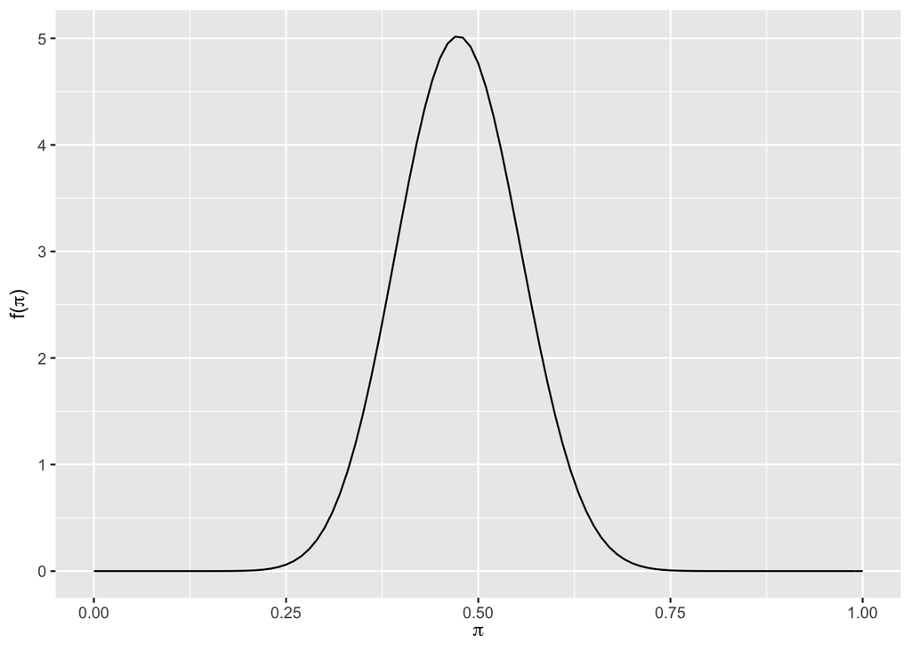

```r
plot_beta(19,21)
```

b&c) We’re given y = 80 and n = 200 to use to update our prior.

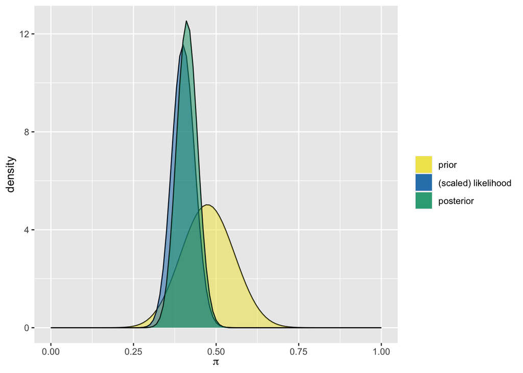

```r
plot_beta_binomial(alpha = 19, beta = 21, y = 80, n = 200)
```

```r
summarize_beta_binomial(alpha = 19, beta = 80, y = 80, n = 200)
```

[output not shown]

## Exercise 3.14

1. We’re asked to write the input code for the output which is essentially asking us to solve for y and n. We know the prior is Beta (2,3). We can see that the posterior has an alpha that’s less than beta and that the mean is about .30. The low variance tells us the posterior alpha and beta are lower numbers. Using guess and check I found that y = 9 and n = 30.

```r
summarize_beta_binomial(alpha = 2, beta = 3, y = 9, n = 30)
```

```
##       model alpha beta      mean      mode         var         sd
## 1     prior     2    3 0.4000000 0.3333333 0.040000000 0.20000000
## 2 posterior    11   24 0.3142857 0.3030303 0.005986395 0.07737179
```

I could have also been more precise by using pi|(Y=y)~Beta(alpha + y, B+ n- y) where alpha + y = 11 and beta + n - y = 24 and where alpha = 2 and beta = 3

2 + y = 11 so y = 9 3 + n - y = 24

n = 30 ## Exercise 3.15

1. The mean and mode are high and variance is low. The posterior alpha is much greater than the beta. Therefore we know that y will be closer to n in this simulation. Using this prior knowledge and guess and check I arrived at the below input code.

```r
summarize_beta_binomial(alpha = 1, beta = 2, y = 99, n = 100)
```

```
##       model alpha beta      mean     mode          var         sd
## 1     prior     1    2 0.3333333 0.000000 0.0555555556 0.23570226
## 2 posterior   100    3 0.9708738 0.980198 0.0002719027 0.01648947
```

I could have been more precise like the first one by using pi|(Y=y)~Beta(alpha + y, B+ n- y) where alpha + y = 100 and beta + n - y = 3 and where alpha = 1 and beta = 2

1 + y = 100 so y = 99

2+ n - 99 = 3 2+ n = 102 n=100

## Exercise 3.16

1. The prior model is left-skewed which tells me alpha > beta; the shape also indicates that alpha is much greater than beta in the prior. The prior has no overlap with the likelihood.
2. The posterior is symmetrical around 0.75 so pi is equally likely to be above or below 0.75. The posterior has a shape more similar to the likelihood so it more so agrees with the data than with the prior. The likelihood has a right skew and has more spread.

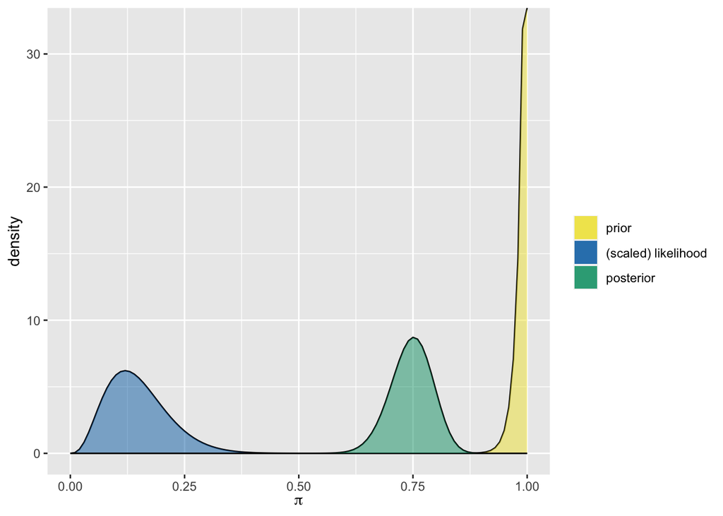

```r
#Using educated guess and check to plot beta-binomial that looks similar to one shown in exercise 3.16

plot_beta_binomial(alpha = 64, beta = .8, y = 3, n = 25) #chose a beta less than 1 becuase the prior has an asymptote near 1 and chose double digit alpha to get density to have a scale of 30. Chose y = 3 and n = 25 to produce a posterior with a mean around .75.
```

```r
summarize_beta_binomial(alpha = 64, beta = .8, y = 3, n = 25) # This is similar in that liklihood is to the left of the posterior and posterior is to the left of the prior.  The prior has alpha > beta and is left-skewed.
```

```
##       model alpha beta      mean      mode         var         sd
## 1     prior    64  0.8 0.9876543 1.0000000 0.000185308 0.01361279
## 2 posterior    67 22.8 0.7461024 0.7517084 0.002086273 0.04567574
```

## Exercise 3.17

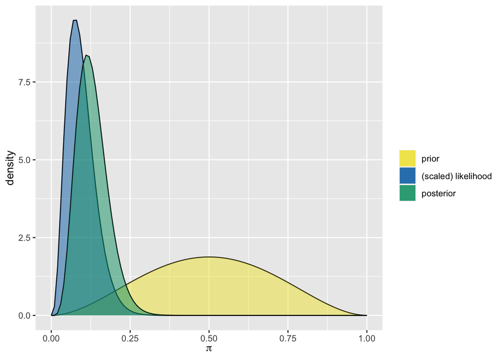

```r
#using guess and check to find similar beta binomial plot.
plot_beta_binomial(alpha = 3, beta = 3, y = 3, n = 40)
```

```r
summarize_beta_binomial(alpha = 3, beta = 3, y = 3, n = 40) #This is similar to the plot shown in the figure since the density and pi have the same scale and the shapes for the prior, likelihood, and posterior align. I knew I needed a larger sample than 3.16 because these peaks are narrower.
```

```
##       model alpha beta      mean      mode         var         sd
## 1     prior     3    3 0.5000000 0.5000000 0.035714286 0.18898224
## 2 posterior     6   40 0.1304348 0.1136364 0.002413224 0.04912458
```

## Exercise 3.18

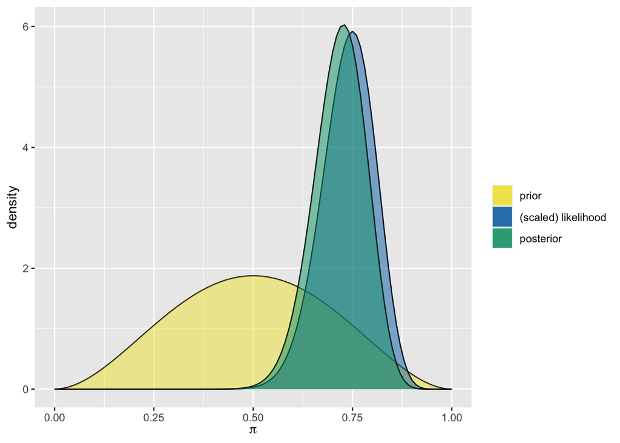

```r
#Plotting and summarizing Patrick's analysis.
plot_beta_binomial(alpha = 3, beta = 3, y = 30, n = 40) #Beta(3,3) and 30/40 attending protest
```

```r
summarize_beta_binomial(alpha = 3, beta = 3, y = 30, n = 40)
```

```
##       model alpha beta      mean      mode         var        sd
## 1     prior     3    3 0.5000000 0.5000000 0.035714286 0.1889822
## 2 posterior    33   13 0.7173913 0.7272727 0.004313639 0.0656783
```

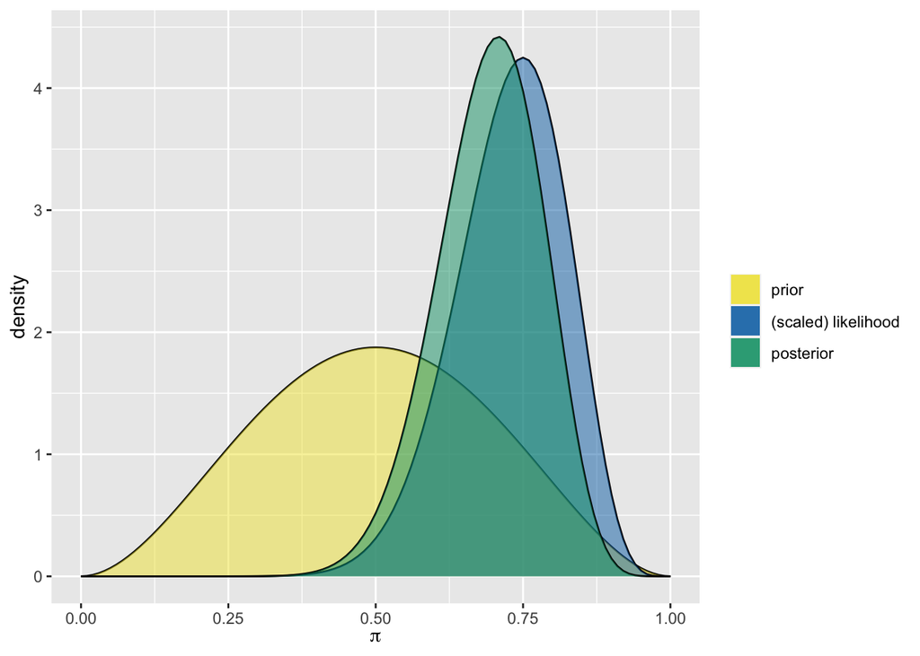

```r
#Plotting and summarizing Harold's analysis.
plot_beta_binomial(alpha = 3, beta = 3, y = 15, n = 20) #Beta(3,3) and 15/20 attending protest
```

```r
summarize_beta_binomial(alpha = 3, beta = 3, y = 15, n = 20)
```

```
##       model alpha beta      mean      mode         var         sd
## 1     prior     3    3 0.5000000 0.5000000 0.035714286 0.18898224
## 2 posterior    18    8 0.6923077 0.7083333 0.007889546 0.08882312
```

3. Patrick’s and Harold’s posterior models have a similar shape owing to their means being close. Patricks’s shape is narrower around the mean given he has a larger sample than does Harold.